# **Working with Data**

Modifications:** Giorgi Nikolaishvili **Original Authors:** Undetermined Group of Past PhD Students EC 320: Introduction to Econometrics University of Oregon

Spring 2022

## Recap

What we learned last week:

- Math operators in R
- Variables (objects) in R
- Functions in R
- Variable classes in R
- Loading packages (using `pacman`)
- Data frames
- Basic plotting (using `ggplot2`)

Some notes on the computational assignment and other more general notes:

- You should never hard-code / manually copy any values from a dataset!

```r
x <- mean(mtcars$mpg)
x
```

```
## [1] 20.09062
```

- `.Rmd` files don’t knit when your code has a line with `install.packages()` in which you are installing a package that already exists on your machine. Generally, you should only use `install.packages()` in the console – after you’ve installed a package once, it will exist on your computer forever. Many of you put the `install.packages("pacman")` line in your `.Rmd`s and ran into knitting issues – after the initial installation of `pacman` you only need to use `library(pacman)` to load the `pacman` package, and then simply use the `p_load` function to install/load other packages you need.
- Get started with your computational assignments early! There is no guarantee that I will be able to help you out if you run into issues on the day of the deadline.
- If you have questions, you should: **(1)** come to my office hours; **(2)** if you can’t do (1) then you should send me an email in which you state a specific question or problem you are running into; **(3)** if you don’t have a specific question/problem and instead are simply confused/lost/unsure, then refer to (1) or email me to schedule a one-on-one meeting in which I can set you on the right track.
- Please don’t email me an attachment of all of your work with the question ``Am I doing everything right?’’ :~) I can’t answer a general question like that for a variety of practical and ethical reasons.
- **Attend the labs or watch the full recording. Not every piece of necessary information will be given in these lab note documents – I might mention and demonstrate crucial concepts on the fly.**

## Writing and Reading `.csv` Files

The `mtcars` dataset comes pre-loaded with R for us to play around with.

Suppose I want to save `mtcars` as a `.csv` file on my computer.

I would use the `write.csv` function to do so.

The first input to this function is the data frame object in question. The second input is the path for the `.csv` file that is to be written (including the name of the file at the very end).

```r
# Save `mtcars` dataframe as `.csv` file
write.csv(mtcars, "C:/Users/gioni/Box/uo_phd_y3/spring_ec320/EC320s22/labs/02-working-with-data/data.csv")
```

In the above chunk, I’ve saved `mtcars` as a `.csv` file called `data.csv` in a specific directory (folder) on my computer.

Now, suppose I would like to import the data in `data.csv` and store it in a dataframe called `df` in my current instance of R.

I would use the `read.csv` function to do so.

```r
# Import `data.csv` and store as data frame
df <- read.csv(file = "C:/Users/gioni/Box/uo_phd_y3/spring_ec320/EC320s22/labs/02-working-with-data/data.csv")
```

Let’s preview the new data frame `df` to convince ourselves that the above code did its job:

```r
df
```

```
##                      X  mpg cyl  disp  hp drat    wt  qsec vs am gear carb
## 1            Mazda RX4 21.0   6 160.0 110 3.90 2.620 16.46  0  1    4    4
## 2        Mazda RX4 Wag 21.0   6 160.0 110 3.90 2.875 17.02  0  1    4    4
## 3           Datsun 710 22.8   4 108.0  93 3.85 2.320 18.61  1  1    4    1
## 4       Hornet 4 Drive 21.4   6 258.0 110 3.08 3.215 19.44  1  0    3    1
## 5    Hornet Sportabout 18.7   8 360.0 175 3.15 3.440 17.02  0  0    3    2
## 6              Valiant 18.1   6 225.0 105 2.76 3.460 20.22  1  0    3    1
## 7           Duster 360 14.3   8 360.0 245 3.21 3.570 15.84  0  0    3    4
## 8            Merc 240D 24.4   4 146.7  62 3.69 3.190 20.00  1  0    4    2
## 9             Merc 230 22.8   4 140.8  95 3.92 3.150 22.90  1  0    4    2
## 10            Merc 280 19.2   6 167.6 123 3.92 3.440 18.30  1  0    4    4
## 11           Merc 280C 17.8   6 167.6 123 3.92 3.440 18.90  1  0    4    4
## 12          Merc 450SE 16.4   8 275.8 180 3.07 4.070 17.40  0  0    3    3
## 13          Merc 450SL 17.3   8 275.8 180 3.07 3.730 17.60  0  0    3    3
## 14         Merc 450SLC 15.2   8 275.8 180 3.07 3.780 18.00  0  0    3    3
```

[output cut: 18 more lines]

The `read.csv` function automatically saves the dataset as a data frame:

```r
class(df)
```

```
## [1] "data.frame"
```

Alternatively, we could convert the data frame object `df` to a “tibble”:

```r
df <- as.tbl(df)
df
```

```
## # A tibble: 32 x 12
##    X             mpg   cyl  disp    hp  drat    wt  qsec    vs    am  gear  carb
##    <fct>       <dbl> <int> <dbl> <int> <dbl> <dbl> <dbl> <int> <int> <int> <int>
##  1 Mazda RX4    21       6  160    110  3.9   2.62  16.5     0     1     4     4
##  2 Mazda RX4 ~  21       6  160    110  3.9   2.88  17.0     0     1     4     4
##  3 Datsun 710   22.8     4  108     93  3.85  2.32  18.6     1     1     4     1
##  4 Hornet 4 D~  21.4     6  258    110  3.08  3.22  19.4     1     0     3     1
##  5 Hornet Spo~  18.7     8  360    175  3.15  3.44  17.0     0     0     3     2
##  6 Valiant      18.1     6  225    105  2.76  3.46  20.2     1     0     3     1
##  7 Duster 360   14.3     8  360    245  3.21  3.57  15.8     0     0     3     4
##  8 Merc 240D    24.4     4  147.    62  3.69  3.19  20       1     0     4     2
##  9 Merc 230     22.8     4  141.    95  3.92  3.15  22.9     1     0     4     2
## 10 Merc 280     19.2     6  168.   123  3.92  3.44  18.3     1     0     4     4
## # ... with 22 more rows
```

Tibble is an extremely similar alternative object class to data frame that is provided by the `tidyverse` package. We will not go into details on tibble vs. data frame here, but the above was worth showing since you are asked to convert a data frame object to a tibble in your next computational assignment. For now, you can think of tibbles and data frames as being interchangeable object classes.

## Working Directory

If you have a large hierarchy of directories (folders) on your computer like I do, it may get cumbersome to keep typing out the full paths of datasets you want to import.

For this reason, it is useful give R directions on how to reach your desired dataset relative to your present **working directory** – this is the directory (folder) that R treats as an anchor (where R thinks you are currently “working”).

Find your current directory: `getwd()`. “wd” stands for “working directory”.

```r
getwd()
```

```
## [1] "C:/Users/gioni/Box/uo_phd_y3/spring_ec320/EC320s22/labs/02-working-with-data"
```

Show files in the current directory: `dir()`

```r
dir()
```

```
## [1] "02-working-with-data.html"  "02-working-with-data.Rmd"
## [3] "02-working-with-data_cache" "02-working-with-data_files"
## [5] "data.csv"                   "newfolder"
```

Change directory: `setwd()`

```r
setwd("C:/Users/gioni/Box/uo_phd_y3/spring_ec320/EC320s22/labs/02-working-with-data/newfolder")
```

Notice that directories are characters (surrounded by `""`).

RStudio will help you complete file paths when you hit tab while typing in the console.

You can save an object with the directory location and then return to that directory using `setwd()`.

Example:

```r
my_dir <- "C:/Users/gioni/Box/uo_phd_y3/spring_ec320/EC320s22/labs/02-working-with-data"
setwd(my_dir)
```

Now let’s try importing the `data.csv` file relative to our working directory:

```r
df <- read.csv(file = "data.csv")
```

What if we wanted to write the `data.csv` file in the `newfolder` subdirectory instead?

```r
write.csv(mtcars, "newfolder/data.csv")
```

To import the above dataset:

```r
df <- read.csv(file = "newfolder/data.csv")
```

The above paths to the `.csv` file relative to the current working directory are called **relative paths**.

## Tidy Data

Data can be **messy**, or it can be **tidy**.

**Tidy data** has the following properties:

- Every columns is a variable.
- Every row is an observation.
- Every cell is a single value.

**Messy data** is any other arrangement of data. It can come in many forms, and usually needs to be thoroughly “cleaned” before it can be analyzed. Tidy data makes it easy for an analyst or a computer to extract needed variables because it provides a standard way of structuring a dataset.

### Example: `gapminder`

`gapminder` is a dataset that lives in the `gapminder` R package and contains data on countries’ total population, GDP per capita, and life expectancy over time. The dataset contains the following variables:

- `gdpPercap`: GDP per capita of a country in a given year.
- `pop`: Population of a country in a given year.
- `lifeExp`: Life expectancy in a country in a given year.
- `year`: The year in which an observation was taken.
- `continent`: The continent to which a country associated with a given observation belongs.
- `country`: The country with which a given observation is associated.

Let’s load the `tidyverse` and `gapminder` packages to start working with this data.

```r
library(pacman)
p_load(tidyverse, gapminder)
```

Print the dataset:

```r
gapminder
```

```
## # A tibble: 1,704 x 6
##    country     continent  year lifeExp      pop gdpPercap
##    <fct>       <fct>     <int>   <dbl>    <int>     <dbl>
##  1 Afghanistan Asia       1952    28.8  8425333      779.
##  2 Afghanistan Asia       1957    30.3  9240934      821.
##  3 Afghanistan Asia       1962    32.0 10267083      853.
##  4 Afghanistan Asia       1967    34.0 11537966      836.
##  5 Afghanistan Asia       1972    36.1 13079460      740.
##  6 Afghanistan Asia       1977    38.4 14880372      786.
##  7 Afghanistan Asia       1982    39.9 12881816      978.
##  8 Afghanistan Asia       1987    40.8 13867957      852.
##  9 Afghanistan Asia       1992    41.7 16317921      649.
## 10 Afghanistan Asia       1997    41.8 22227415      635.
## # ... with 1,694 more rows
```

Print the first few observations of the dataset using the `head()` function:

```r
head(gapminder)
```

```
## # A tibble: 6 x 6
##   country     continent  year lifeExp      pop gdpPercap
##   <fct>       <fct>     <int>   <dbl>    <int>     <dbl>
## 1 Afghanistan Asia       1952    28.8  8425333      779.
## 2 Afghanistan Asia       1957    30.3  9240934      821.
## 3 Afghanistan Asia       1962    32.0 10267083      853.
## 4 Afghanistan Asia       1967    34.0 11537966      836.
## 5 Afghanistan Asia       1972    36.1 13079460      740.
## 6 Afghanistan Asia       1977    38.4 14880372      786.
```

Print the last few observations of the dataset using the `tail()` function:

```r
tail(gapminder)
```

```
## # A tibble: 6 x 6
##   country  continent  year lifeExp      pop gdpPercap
##   <fct>    <fct>     <int>   <dbl>    <int>     <dbl>
## 1 Zimbabwe Africa     1982    60.4  7636524      789.
## 2 Zimbabwe Africa     1987    62.4  9216418      706.
## 3 Zimbabwe Africa     1992    60.4 10704340      693.
## 4 Zimbabwe Africa     1997    46.8 11404948      792.
## 5 Zimbabwe Africa     2002    40.0 11926563      672.
## 6 Zimbabwe Africa     2007    43.5 12311143      470.
```

Print basic summary statistics on each of the variables contained by the dataset using the `summary()` function:

```r
summary(gapminder)
```

```
##         country        continent        year         lifeExp
##  Afghanistan:  12   Africa  :624   Min.   :1952   Min.   :23.60
##  Albania    :  12   Americas:300   1st Qu.:1966   1st Qu.:48.20
##  Algeria    :  12   Asia    :396   Median :1980   Median :60.71
##  Angola     :  12   Europe  :360   Mean   :1980   Mean   :59.47
##  Argentina  :  12   Oceania : 24   3rd Qu.:1993   3rd Qu.:70.85
##  Australia  :  12                  Max.   :2007   Max.   :82.60
##  (Other)    :1632
##       pop              gdpPercap
##  Min.   :6.001e+04   Min.   :   241.2
##  1st Qu.:2.794e+06   1st Qu.:  1202.1
##  Median :7.024e+06   Median :  3531.8
##  Mean   :2.960e+07   Mean   :  7215.3
##  3rd Qu.:1.959e+07   3rd Qu.:  9325.5
##  Max.   :1.319e+09   Max.   :113523.1
##
```

## Selecting Subsamples

Let’s the `country`, `year`, and `pop` variables and store it all together in a new tibble object called `df_countrypop`.

The `tidyverse` package provides us a handy function called `select` that allows us to grab a select set of variables from a data frame.

```r
df_countrypop <- gapminder %>% select(country, year, pop)
df_countrypop
```

```
## # A tibble: 1,704 x 3
##    country      year      pop
##    <fct>       <int>    <int>
##  1 Afghanistan  1952  8425333
##  2 Afghanistan  1957  9240934
##  3 Afghanistan  1962 10267083
##  4 Afghanistan  1967 11537966
##  5 Afghanistan  1972 13079460
##  6 Afghanistan  1977 14880372
##  7 Afghanistan  1982 12881816
##  8 Afghanistan  1987 13867957
##  9 Afghanistan  1992 16317921
## 10 Afghanistan  1997 22227415
## # ... with 1,694 more rows
```

The pipe operator, written as `%>%`, takes the output of one function and passes it into another function as an argument. This allows us to link a sequence of analysis steps.

In the above code chunk, the pipe operator automatically gives `select()` the `gapminder` tibble as an input, so that `select()` knows that `country`, `year`, and `pop` are columns that belong to `gapminder`.

The pipe operator is extremely useful! Start playing around with it – you will rely on it heavily this quarter.

Alternatively (note that this is bad practice) you could have written

```r
# DO NOT do the following in your code!!!
df_countrypop <- select(gapminder, country, year, pop) # This is bad.
df_countrypop
```

```
## # A tibble: 1,704 x 3
##    country      year      pop
##    <fct>       <int>    <int>
##  1 Afghanistan  1952  8425333
##  2 Afghanistan  1957  9240934
##  3 Afghanistan  1962 10267083
##  4 Afghanistan  1967 11537966
##  5 Afghanistan  1972 13079460
##  6 Afghanistan  1977 14880372
##  7 Afghanistan  1982 12881816
##  8 Afghanistan  1987 13867957
##  9 Afghanistan  1992 16317921
## 10 Afghanistan  1997 22227415
## # ... with 1,694 more rows
```

Now, suppose we only care about population data on the United States. Let’s take the `df_countrypop` tibble we’ve just created and filter for US-related data only using the `filter()` function. Once again, we should use the pipe operator.

```r
df_usapop <- df_countrypop %>% filter(country == "United States")
df_usapop
```

```
## # A tibble: 12 x 3
##    country        year       pop
##    <fct>         <int>     <int>
##  1 United States  1952 157553000
##  2 United States  1957 171984000
##  3 United States  1962 186538000
##  4 United States  1967 198712000
##  5 United States  1972 209896000
##  6 United States  1977 220239000
##  7 United States  1982 232187835
##  8 United States  1987 242803533
##  9 United States  1992 256894189
## 10 United States  1997 272911760
## 11 United States  2002 287675526
## 12 United States  2007 301139947
```

The above sequence of steps is equivalent to having done the following in one go:

```r
df_usapop <- gapminder %>%
              select(country, year, pop) %>%
              filter(country == "United States")
```

Note the use of `==` inside of `filter` in the above code chunk. A single equal sign `=` acts as an assignment operator, while the double equal sign `==` is a **relational** operator that yields “TRUE” if two objects are equal and “FALSE” otherwise.

The `filter(country == "United States")` command basically skims through all observations inside of the `gapminder %>% select(country, year, pop)` dataset and for each observation says “if the value of the `country` variable in this observation is equal to”United States”, then keep this observation – if not, then discard this observation”. Or equivalenty “if `country == "United States"` is true for this observation, then keep it – discard otherwise.”

Let’s quickly plot the data we’ve gathered in `df_usapop`:

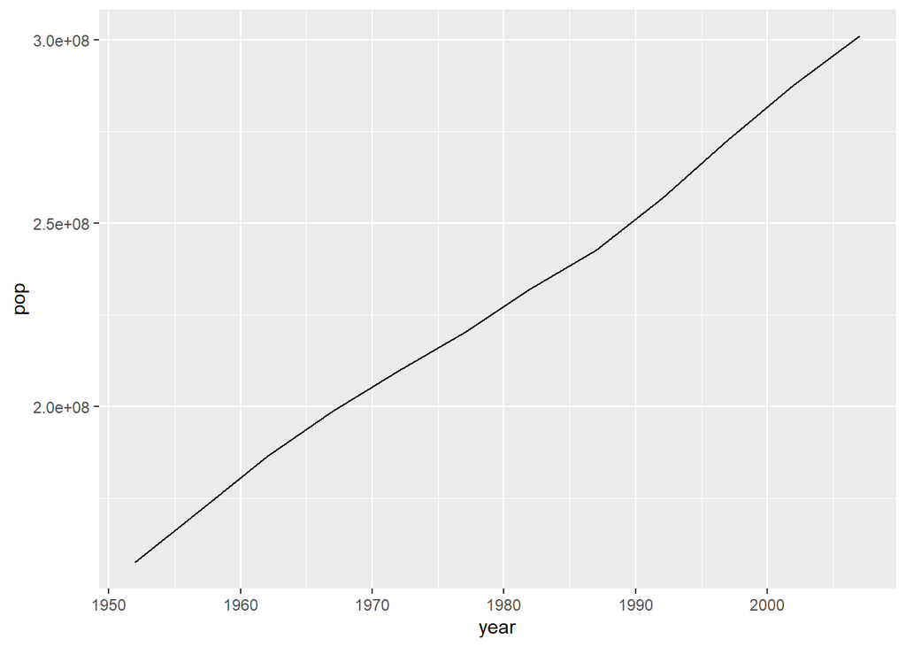

```r
ggplot(df_usapop, aes(x = year, y = pop)) +
  geom_line()
```

## Transforming Data

We can easily create a new column of data and add it to `df_usapop` by transforming the existing columns.

For example, suppose we want to express the total population values `pop` in millions and store it in a new column called `popmil`:

```r
df_usapop <- df_usapop %>%
              mutate(popmil = pop/1000000)
df_usapop
```

```
## # A tibble: 12 x 4
##    country        year       pop popmil
##    <fct>         <int>     <int>  <dbl>
##  1 United States  1952 157553000   158.
##  2 United States  1957 171984000   172.
##  3 United States  1962 186538000   187.
##  4 United States  1967 198712000   199.
##  5 United States  1972 209896000   210.
##  6 United States  1977 220239000   220.
##  7 United States  1982 232187835   232.
##  8 United States  1987 242803533   243.
##  9 United States  1992 256894189   257.
## 10 United States  1997 272911760   273.
## 11 United States  2002 287675526   288.
## 12 United States  2007 301139947   301.
```

Let’s visual `popmil` now as a timeplot.

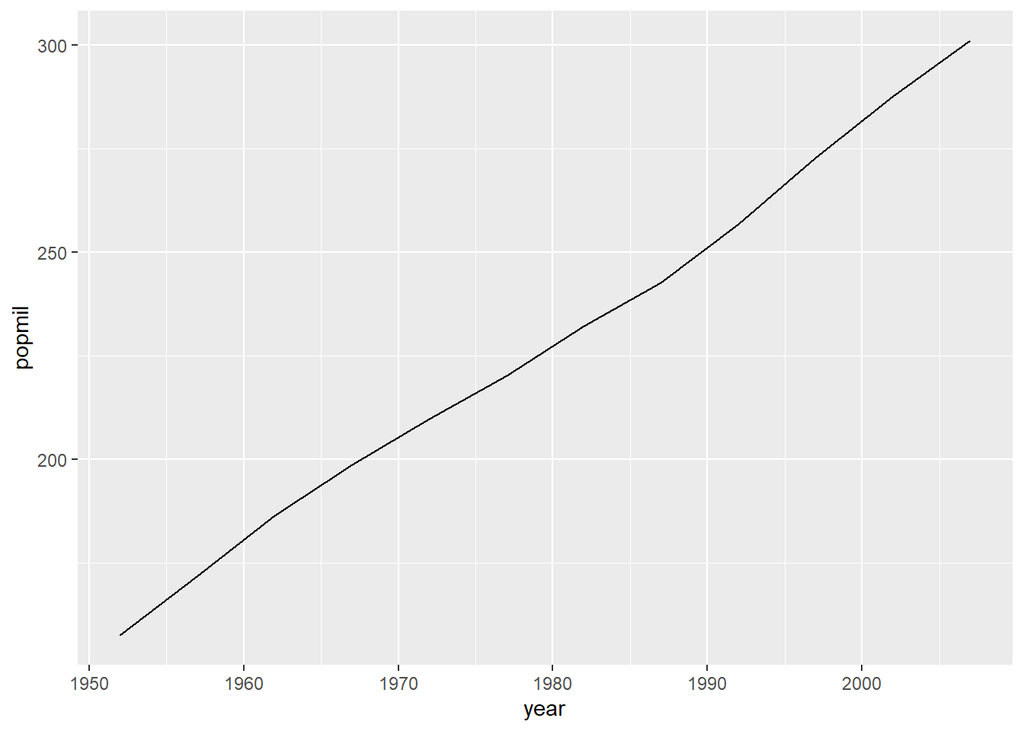

```r
ggplot(df_usapop, aes(x = year, y = popmil)) +
  geom_line()
```

## Ordering Data

Now let’s focus on the life expectancy data of all countries in the year 1992. We can easily gather the above data in a new object called `df_lifeExp92` using some of the tools we’ve learned so far:

```r
df_lifeExp92 <- gapminder %>%
                select(country, year, lifeExp) %>%
                filter(year == 1992)
df_lifeExp92
```

```
## # A tibble: 142 x 3
##    country      year lifeExp
##    <fct>       <int>   <dbl>
##  1 Afghanistan  1992    41.7
##  2 Albania      1992    71.6
##  3 Algeria      1992    67.7
##  4 Angola       1992    40.6
##  5 Argentina    1992    71.9
##  6 Australia    1992    77.6
##  7 Austria      1992    76.0
##  8 Bahrain      1992    72.6
##  9 Bangladesh   1992    56.0
## 10 Belgium      1992    76.5
## # ... with 132 more rows
```

We may use the `arrange()` function to order all of the observations in `df_lifeExp92` in increasing order with respect to the values in `lifeExp`.

```r
df_lifeExp92 <- df_lifeExp92 %>%
                arrange(lifeExp)
df_lifeExp92
```

```
## # A tibble: 142 x 3
##    country           year lifeExp
##    <fct>            <int>   <dbl>
##  1 Rwanda            1992    23.6
##  2 Sierra Leone      1992    38.3
##  3 Somalia           1992    39.7
##  4 Angola            1992    40.6
##  5 Liberia           1992    40.8
##  6 Afghanistan       1992    41.7
##  7 Guinea-Bissau     1992    43.3
##  8 Mozambique        1992    44.3
##  9 Burundi           1992    44.7
## 10 Congo, Dem. Rep.  1992    45.5
## # ... with 132 more rows
```

Similarly, we may us ethe `desc()` function inside of `arrange()` to order the observations in decreasing order with respect to `lifeExp`.

```r
df_lifeExp92 <- df_lifeExp92 %>%
                arrange(desc(lifeExp))
df_lifeExp92
```

```
## # A tibble: 142 x 3
##    country           year lifeExp
##    <fct>            <int>   <dbl>
##  1 Japan             1992    79.4
##  2 Iceland           1992    78.8
##  3 Sweden            1992    78.2
##  4 Switzerland       1992    78.0
##  5 Canada            1992    78.0
##  6 Hong Kong, China  1992    77.6
##  7 Spain             1992    77.6
##  8 Australia         1992    77.6
##  9 France            1992    77.5
## 10 Italy             1992    77.4
## # ... with 132 more rows
```